# MATH 3190 Homework 1

Focus: Notes 1-3

Due February 9, 2024

Now its time to practice what we have learned in class and learn even more! Note that your homework should be completed in R Markdown or Quarto (you can just add your answers to this document in the appropriate part) and Knitted to an html document or pdf document. You will `turn in’ this homework by uploading to your GitHub Math_3190_Assignment repository in the Homework/Homework_1 directory.

# Problem 1 (25 points)

### Part a (20 points)

Write two functions called `ghist` and `gbox` that are similar to my `ggraph` function that you put in your myplots.in package from Lab 2. Remember that the “in” should be replaced with your initials. The `ghist` function should create a ggplot histogram of a variable that is given as a vector. The `gbox` function should create a ggplot box plot when a single numeric vector is given or it should create side-by-side box plots if one numeric and one categorical variables are given. Allow the user to indicate whether it should be horizontal or vertical box plots. Be sure to properly document these functions.

### Part b (3 points)

Add those functions to your myplots.in package. Then run the `devtools::document()` function, update the DESCRIPTION file, and install your package to verify those functions work.

### Part c (2 points)

Update your GitHub myplots.in repo with the updated package. This is only worth 2 points, but I cannot verify you did part a without this, so it is actually worth much more.

# Problem 2 (60 points)

### Part a (9 points)

Learn about the `read.fwf()` function for use in downloading data from a URL into **R**. Learn about tools for downloading files from external servers. The `widths` and `strip.white` options will be especially useful here. Use this function to download the scores for all college basketball games for the 2023-2024 season (http://kenpom.com/cbbga24.txt) and then convert it to a tibble (load the `tidyverse` package first). The second team listed per line is the home team. It is not clear what the numbers, letters, or city names indicate after the second listed score. Notice that this is a “live” file that gets updated every day! So, your tibble size may change if you work on this assignment over the course of several days. That’s fine. Give the code you used to download these data.

```r
library(tidyverse)
library(dplyr)
library(magrittr)
```

```r
library(ggplot2)
library(readr)
```

```r
cbbga24 <- read.fwf("http://kenpom.com/cbbga24.txt", widths = c(11, 23, 3, 23, 4, 5, 15), strip.white = TRUE, header = FALSE)
```

Now lets practice using our tidy data/tidyverse tools! Using your `cbbga24` tibble, try doing the following:

### Part b (2 points)

Use `rename()` to rename all of your variables to names that make sense.

```r
cbbga24 <- as_tibble(cbbga24)
cbbga24 <- rename(cbbga24, "Date" = "V1", "Away" = "V2", "AwayPts" = "V3", "Home" = "V4", "HomePts" = "V5",
       "Neutral?" = "V6", "Site" = "V7"   )
```

### Part c (2 points)

Use `mutate()` to create a new column that gives the score differences (team1$-$team2).

```r
  cbbga24 |>
  mutate(Diff = AwayPts - HomePts)
```

```
## # A tibble: 4,452 × 8
##    Date       Away         AwayPts Home           HomePts `Neutral?` Site   Diff
##    <chr>      <chr>          <int> <chr>            <int> <chr>      <chr> <int>
##  1 11/06/2023 Portland St.      62 Air Force           55 ""         <NA>      7
##  2 11/06/2023 Morehead St.      73 Alabama            105 ""         <NA>    -32
##  3 11/06/2023 Morgan St.        59 Arizona            122 ""         <NA>    -63
##  4 11/06/2023 Alcorn St.        59 Arkansas            93 ""         <NA>    -34
##  5 11/06/2023 Marist            71 Army                55 ""         <NA>     16
##  6 11/06/2023 Life              72 Austin Peay         90 ""         <NA>    -18
##  7 11/06/2023 Georgia St.       87 Belmont             89 ""         <NA>     -2
##  8 11/06/2023 Fairfield         70 Boston College      89 ""         <NA>    -19
##  9 11/06/2023 Chicago St.       41 Bowling Green       70 ""         <NA>    -29
## 10 11/06/2023 Manhattan         61 Bryant              59 ""         <NA>      2
## # … with 4,442 more rows
```

### Part d (2 points)

Use `arrange()` to sort the data set by the home team.

```r
cbbga24 |>
  arrange(Home)
```

```
## # A tibble: 4,452 × 7
##    Date       Away                 AwayPts Home            HomePts Neutr…¹ Site
##    <chr>      <chr>                  <int> <chr>             <int> <chr>   <chr>
##  1 11/14/2023 Prairie View A&M          79 Abilene Christ…      74 ""      <NA>
##  2 11/19/2023 Fordham                   45 Abilene Christ…      59 "N"     St. …
##  3 12/02/2023 Stephen F. Austin         79 Abilene Christ…      74 "1"     <NA>
##  4 12/06/2023 Northern Arizona          78 Abilene Christ…      76 ""      <NA>
##  5 12/10/2023 Howard Payne              69 Abilene Christ…     120 ""      <NA>
##  6 12/17/2023 UTEP                      82 Abilene Christ…      88 ""      <NA>
##  7 01/06/2024 UT Rio Grande Valley      89 Abilene Christ…      91 "1"     <NA>
##  8 01/20/2024 UT Arlington              67 Abilene Christ…      78 ""      <NA>
##  9 01/25/2024 Utah Tech                 60 Abilene Christ…      82 ""      <NA>
## 10 01/27/2024 Southern Utah             82 Abilene Christ…      67 ""      <NA>
## # … with 4,442 more rows, and abbreviated variable name ¹`Neutral?`
```

### Part e (2 points)

Use `select()` to remove the extra variable(s) that had that irrelevant information at the end of each line. Note: you can select every variable except one by using the “!”.

```r
cbbga24 |>
  select(!c("Neutral?", "Site"))
```

```
## # A tibble: 4,452 × 5
##    Date       Away         AwayPts Home           HomePts
##    <chr>      <chr>          <int> <chr>            <int>
##  1 11/06/2023 Portland St.      62 Air Force           55
##  2 11/06/2023 Morehead St.      73 Alabama            105
##  3 11/06/2023 Morgan St.        59 Arizona            122
##  4 11/06/2023 Alcorn St.        59 Arkansas            93
##  5 11/06/2023 Marist            71 Army                55
##  6 11/06/2023 Life              72 Austin Peay         90
##  7 11/06/2023 Georgia St.       87 Belmont             89
##  8 11/06/2023 Fairfield         70 Boston College      89
##  9 11/06/2023 Chicago St.       41 Bowling Green       70
## 10 11/06/2023 Manhattan         61 Bryant              59
## # … with 4,442 more rows
```

### Part f (2 points)

Put parts a-e all together in one piping expression (with 5 pipes) and save this as a new object in **R**.

```r
cbbga24 <-
  read.fwf("http://kenpom.com/cbbga24.txt", widths = c(11, 23, 3, 23, 4, 5, 15),
           strip.white = TRUE, header = FALSE) |> # a
  rename("Date" = "V1", "Away" = "V2", "AwayPts" = "V3", "Home" = "V4",
         "HomePts" = "V5", "Neutral?" = "V6", "Site" = "V7" ) |> # b
  mutate(Diff = AwayPts - HomePts) |> # c
  arrange(Home) |> # d
  select(!c("Neutral?", "Site"))  # e
```

### Part g (3 points)

Use `filter()` to reduce the data down to only games played in 2023 (you could use the `lubridate` package for this, since it specializes in dealing with dates, but some base **R** packages will also work). Save this in a new tibble. **We will use this tibble with only the 2023 years from here on out**.

```r
cbbga23 <- cbbga24 |>
    mutate(Date = mdy(Date)) |>
    filter(Date < '2024-01-01')
as_tibble(cbbga23)
```

```
## # A tibble: 2,634 × 6
##    Date       Away              AwayPts Home              HomePts  Diff
##    <date>     <chr>               <int> <chr>               <int> <int>
##  1 2023-11-14 Prairie View A&M       79 Abilene Christian      74     5
##  2 2023-11-19 Fordham                45 Abilene Christian      59   -14
##  3 2023-12-02 Stephen F. Austin      79 Abilene Christian      74     5
##  4 2023-12-06 Northern Arizona       78 Abilene Christian      76     2
##  5 2023-12-10 Howard Payne           69 Abilene Christian     120   -51
##  6 2023-12-17 UTEP                   82 Abilene Christian      88    -6
##  7 2023-11-06 Portland St.           62 Air Force              55     7
##  8 2023-11-16 Lindenwood             58 Air Force              76   -18
##  9 2023-11-17 William & Mary         71 Air Force              80    -9
## 10 2023-11-19 Nebraska Omaha         56 Air Force              58    -2
## # … with 2,624 more rows
```

### Part h (4 points)

Write a function that will filter the tibble to only games played by a given team. Demonstrate your function by displaying games played by SUU.

```r
teamGms <- function(team) {
    cbbga23 |>
    filter(Away == team | Home == team)
}

 teamGms("Southern Utah")
```

```
##          Date             Away AwayPts                Home HomePts Diff
## 1  2023-11-06    Southern Utah      72 Cal St. Bakersfield      73   -1
## 2  2023-11-21    Southern Utah      53      Louisiana Tech      67  -14
## 3  2023-12-19    Southern Utah      88         Montana St.      89   -1
## 4  2023-12-16    Southern Utah      74    Northern Arizona      76   -2
## 5  2023-12-02    Southern Utah      63             Seattle      73  -10
## 6  2023-11-09     Life Pacific      73       Southern Utah     108  -35
## 7  2023-11-29      Cal Baptist      91       Southern Utah      66   25
## 8  2023-12-09        Idaho St.      74       Southern Utah      82   -8
## 9  2023-12-22 Middle Tennessee      63       Southern Utah      69   -6
## 10 2023-12-30  Antelope Valley      78       Southern Utah      95  -17
## 11 2023-11-22    Southern Utah      74           Texas St.      67    7
## 12 2023-12-05    Southern Utah      86                Utah      88   -2
## 13 2023-11-14    Southern Utah      84            Utah St.      93   -9
```

### Part i (7 points)

Use `summarize()` to extract SUU’s win/loss record and winning percentage for their 2023 games. Hint: using the `case_when()` function inside of a `mutate()` function to create a new variable that indicates whether SUU won or lost is helpful.

```r
 teamGms("Southern Utah") |>
  mutate(
    Result = case_when(
      (Away == "Southern Utah" & Diff > 0) ~ "Win",
      (Home == "Southern Utah" & Diff < 0) ~ "Win", .default = "Loss")
      ) |>
   summarize(wins = sum(Result == "Win"), loss = sum(Result == "Loss")) |>
   summarize(record = wins/(wins + loss)) |>
  as.numeric()
```

```
## [1] 0.3846154
```

### Part j (7 points)

Generalize this by writing a function that will do this for a given team, and create a tibble with this information for all teams. Arrange this tibble by winning percentage (descending). The `add_row()` function may be useful here.

```r
tmRec <- function(team) {
 teamGms(team) |>
  mutate(
    Result = case_when(
      (Away == team & Diff > 0) ~ "Win",
      (Home == team & Diff < 0) ~ "Win", .default = "Loss")
      ) |>
   summarize(wins = sum(Result == "Win"), loss = sum(Result == "Loss")) |>
   summarize(record = wins/(wins + loss)) |>
   as.numeric()


}
tmRec("Southern Utah")
```

```
## [1] 0.3846154
```

```r
Teams <- as_tibble(cbbga23)|>
  add_column("Team")|>
  group_by(Home) |>
  group_by(Away) |>
  summarise()

recs23 <- tibble(
  Team = character(),
  Record = numeric()
)
x = 1:710

for(i in 1:710){
 recs23 <-  add_row(recs23, Team = Teams$Away[i], Record = tmRec(Teams$Away[i]))
}
print(recs23)
```

```
## # A tibble: 710 × 2
##    Team              Record
##    <chr>              <dbl>
##  1 Abilene Christian 0.385
##  2 Adams St.         0
##  3 Air Force         0.583
##  4 Akron             0.667
##  5 Alabama           0.615
##  6 Alabama A&M       0.0769
##  7 Alabama St.       0.333
##  8 Albany            0.571
##  9 Albany St.        1
## 10 Alcorn St.        0.0769
## # … with 700 more rows
```

### Part k (8 points)

Write two function that generate appropriate graph for the basketball data. These two graphs could be anything you’d like and should use `ggplot2` and they show something meaningful.

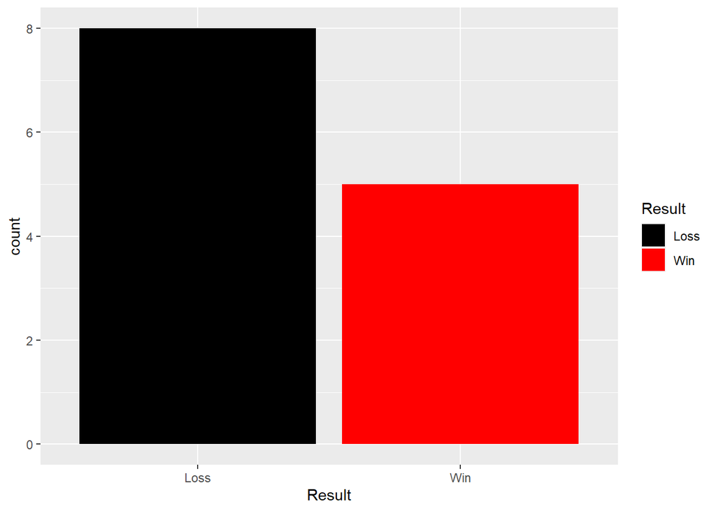

```r
winLoss <- function(team, colors){ #default is black and orange for basketball colors, adjust to team colors
 teamGms(team) |>
  mutate(
    Result = case_when(
      (Away == team & Diff > 0) ~ "Win",
      (Home == team & Diff < 0) ~ "Win", .default = "Loss")
      ) |>
    ggplot(aes(x = Result, fill = Result)) +
    geom_bar() +
    scale_fill_manual(values = c(colors))
}
winLoss("Southern Utah", colors = c("black", "red"))
```

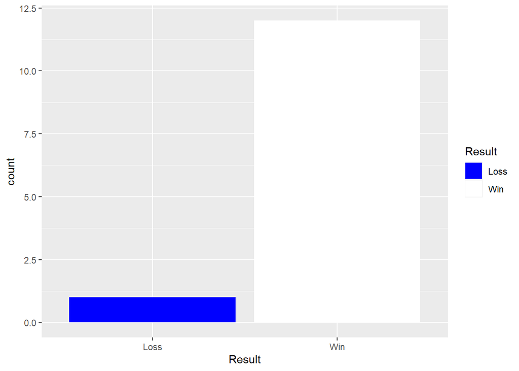

```r
winLoss("BYU", colors = c("blue", "white"))
```

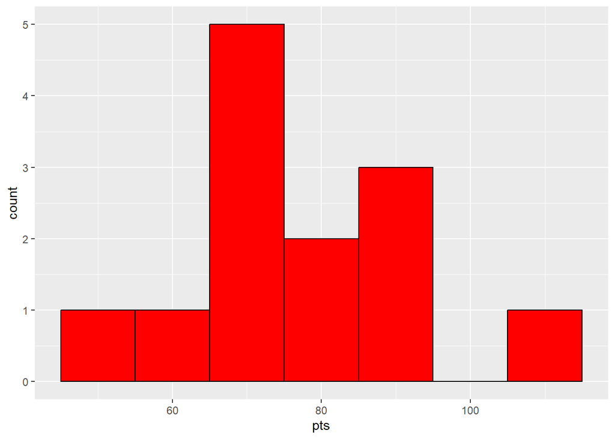

```r
ptsHist <- function(team, color = "black", fill ="orange", bins = 10){ #default is black and orange for basketball colors, adjust to team colors
 teamGms(team) |>
  mutate(
    pts = case_when(
      (Away == team ) ~ AwayPts,
      (Home == team) ~ HomePts, .default = 0)
      ) |>
    ggplot(aes(x = pts)) +
    geom_histogram(color = color, fill = fill, binwidth = bins)
}
ptsHist("Southern Utah", color= "black", fill = "red")
```

### Part l (12 points) Create an **R** package that contains your functions from Parts g, i, and j and your tibble that contains all the games from 2023. You can use the the `write_csv()` function to save your tibble as a .csv file and put it in a `data-raw` folder in your package. Make sure the functions are properly documented. Upload this package to your GitHub page and indicate here what you called this package.

```r
write_csv(x= cbbga23,"/Users/Jun/Documents/MATH3190/hoops/data-raw/cbbga23.csv")
```

# Problem 3 (15 points)

Repeat parts b-f of Problem 2 using Python in R Markdown (or Quarto). First, pass the original object that you read in from the website to Python without any changes to it (you do not need to read the file from the web in Python, but you can if you’d like) and then use `pandas` to rename the columns as indicated in part b, add the columns specified in part c, arrange the data as in part d, drop the “garbage” column as in part e, and filter it down as in part f. The `pandas` functions `rename`, `assign` (instead of `mutate`), `drop` (instead of `select`) and `str.contains` (used to select the right rows) will be useful here. Be sure to follow the guide in Notes 2 to properly install Python, install the `pandas` library and to load it in **R**.

```r
library(tidyverse)
library(dplyr)
cbbga24 <- read.fwf("http://kenpom.com/cbbga24.txt", widths = c(11, 23, 3, 23, 4, 5, 15), strip.white = TRUE, header = FALSE)
```

```python
import pandas as pd
cbbga24 = r.cbbga24
```

```python
cbbga24.columns = ["Date", "Away", "AwayPts", "Home", "HomePts", "idk",
"also idk"]
```

```python
cbbga24['Diff'] = cbbga24.AwayPts - cbbga24.HomePts

cbbga24 = cbbga24.sort_values(by = 'Home', ascending = True)
```

```python
cbbga24 = cbbga24.drop(["idk", "also idk"], axis = 1)
```

```python
cbbga24.Date = pd.to_datetime(cbbga24.Date)
cbbga24['Date'] = cbbga24['Date'] .dt.strftime('%Y/%m/%d')
```

```python
cbbga23 = cbbga24.loc[(cbbga24['Date'] < '2024/01/01')]
```